[figure not shown]

CONTRIBUTED RESEARCH ARTICLE 1

fclust: An R Package for Fuzzy Clustering

by Maria Brigida Ferraro, Paolo Giordani and Alessio Seraﬁni

Abstract

Fuzzy clustering methods discover fuzzy partitions where observations can be softly assigned

to more than one cluster. The package

fclust

is a toolbox for fuzzy clustering in the R programming

language. It not only implements the widely used fuzzy

k

-means (F

k

M) algorithm, but also many F

k

M

variants. Fuzzy cluster similarity measures, cluster validity indices and cluster visualization tools

are also offered. In the current version, all the functions are rewritten in the C++ language allowing

their application in large-size problems. Moreover, new fuzzy relational clustering algorithms for

partitioning qualitative/mixed data are provided together with an improved version of the so-called

Gustafson-Kessel algorithm to avoid singularity in the cluster covariance matrices. Finally, it is now

possible to automatically select the number of clusters by means of the available fuzzy cluster validity

indices.

Introduction

Standard clustering algorithms assign a set of observations to a limited number of clusters such that

observations belonging to the same cluster are more similar to each other than to those in other groups.

Generally speaking, such algorithms usually produce a hard partition of the observations, i. e. every

observation is assigned to one and only one cluster. This may often be too strict leading to unfeasible

partitions. The well-known Butterﬂy dataset (Ruspini, 1970) helps to clarify the problem. It is available

in the matrix

butterfly

of the package

fclust

, provided that the ﬁrst and the last rows of the matrix

are removed.

> data("butterfly", package = "fclust")

> butterfly <- butterfly[-c(1,17),]

> rownames(butterfly) <- as.character(rep(1:nrow(butterfly)))

> plot(butterfly, type = "n", xlab = "Var. 1", ylab="Var. 2")

> text(butterfly[,1], butterfly[,2], labels = rownames(butterfly), cex = 0.7, lwd = 2)

−3 −2 −1 0 1 2 3

−2 −1 0 1 2

Var. 1

Var. 2

1

2

3

4

5

6

7

8 9

10

11

12

13

14

15

Figure 1: Scatterplot of the Butterﬂy data.

The Butterﬂy data refer to 15 observations and 2 variables. Two clusters corresponding to the left

and right wings (observations n.1-n.7 and n.9-n.15, respectively) of the butterﬂy can be graphically

depicted without any need of clustering tools. The assignment of observation n.8 (the body of the

butterﬂy) is a much more complex issue because it is at the halfway between the two clusters. Standard

algorithms fail to assign properly such an observation. For instance, let us consider the (hard)

k

-means

(

k

M) algorithm (Hartigan and Wong, 1979), the most known clustering algorithm. We run the

k

M

algorithm (using the function kmeans) a large number of times (nt).

> set.seed(12)

> nt <- 1000

The R Journal Vol. 11/01, June 2019 ISSN 2073-4859

CONTRIBUTED RESEARCH ARTICLE 2

> ca8 <- rep(NA,nt)

> lfv <- rep(NA,nt)

> for (n in 1: nt){

+ km.butterfly <- kmeans(butterfly, centers = 2, iter.max = 1000, nstart = 10)

+ lfv[n] <- km.butterfly[[5]]

+ if (km.butterfly$cluster[8] == km.butterfly$cluster[1]){

+ ca8[n] <- 1

+ }else{

+ ca8[n] <- 2

+ }

+ }

> summary(lfv)

Min. 1st Qu. Median Mean 3rd Qu. Max.

31.43 31.43 31.43 31.43 31.43 31.43

> table(ca8)

ca8

1 2

560 440

We ﬁnd (details not reported) that the same two clusters are always obtained (the one formed by

observations n-1-n.7, labelled Cluster 1, and the other one by observations n-9-n.15, labelled Cluster 2),

whilst observation n.8 is assigned to one of the two clusters (

ca8

) by chance without affecting the loss

function value (lfv), i. e. the total within sum of squares.

The difﬁculty in the assignment of observation n.8 depends on the fact that it shares the features

of both the groups. This situation frequently occurs in real life applications. In general, it may exist

observations without clear assignments to the clusters. In such cases, it would be desirable to assign

them to the clusters to a certain extent. For instance, in the butterﬂy problem, observation n.8 should

be assigned to the two clusters with the same degree. This goal can be achieved by the fuzzy approach

to clustering where observations belong to clusters with the so-called membership degrees in

[

0, 1

]

and, for each observation, the sum of the membership degrees must be equal to 1. Therefore, in fuzzy

clustering, the observations are not strictly assigned to one and only one cluster, but can share their

memberships to more than one cluster. To differentiate the fuzzy approach from the standard hard

one, it may also be referred to as soft clustering.

The most known fuzzy clustering algorithm is the fuzzy

k

-means (F

k

M), proposed by Bezdek

(1981), which is the fuzzy counterpart of

k

M. It has been implemented in several functions in different

R packages: we mention

cluster

(Maechler et al., 2017),

clue

(Hornik, 2005),

e1071

(Meyer et al., 2017),

skmeans

(Hornik et al., 2012),

vegclust

(De Caceres et al., 2010),

ppclust

(Cebeci et al., 2018) and

fclust

(Ferraro and Giordani, 2015). Among them,

fclust

offers a general toolbox for partitioning data using

fuzzy clustering algorithms, computing cluster validity indices and visualizing clustering results. The

current version (version 2.1.1) of the package has been deeply improved with respect to the previous

ones. It contains several new routines and performance improvements. As a ﬁrst improvement,

all the functions have been rewritten in the C++ language using

Rcpp

(Eddelbuettel, 2013) and

RcppArmadillo

(Eddelbuettel and Sanderson, 2014) to enhance their computational efﬁciency. In

addition, all the clustering algorithms can automatically select the optimal number of clusters using

the cluster validity indexes available in the package. All the functions usually require data organized

by quantitative variables and observations (object data). To increase the usability of the package,

another relevant improvement is the implementation of fuzzy clustering algorithms for relational

data (Davé and Sen, 2002). Relational data come from measures of dissimilarity between observations.

Two clustering methods proposed by Davé and Sen (2002) have been considered. They do not require

any assumption about the adopted measure of dissimilarity. Thus, such algorithms can be applied

to a wide range of data. Speciﬁcally, whilst all the functions for object data require quantitative

variables, those for relational data can handle all kinds of data (quantitative, qualitative or mixed)

provided that a suitable measure of dissimilarity/distance is selected, e. g. the Gower distance (Gower,

1971) specifying the option

metric="gower"

of the function

daisy

in the package

cluster

. Finally, new

functions to compare two partitions in a fuzzy environment have been implemented. Namely, the

fuzzy versions of the Rand index (RI; Rand, 1971), the adjusted Rand index (ARI; Hubert and Arabie,

1985), and the Jaccard index (Jaccard, 1901; Halkidi et al., 2001) have been developed by Campello

(2007). The standard indexes are implemented in different packages (see, for instance, Scrucca et al.,

2016; Chung et al., 2018). The fuzzy vartiants are now available in fclust.

The R Journal Vol. 11/01, June 2019 ISSN 2073-4859

[figure not shown]

CONTRIBUTED RESEARCH ARTICLE 3

In this paper, after reviewing the most relevant fuzzy clustering methods, we recall some of the

original functions to present the new improvements and we introduce the new functions by examples.

We assume that the latest version of fclust available on CRAN is already installed with

> install.packages("fclust")

and loaded into the R session using

> library(fclust)

Fuzzy clustering

In this section, we recall the fuzzy

k

-means algorithm (Bezdek, 1981) and its extension suggested by

Gustafson and Kessel (1979). Whilst the former detects spherical clusters, the latter allows for clusters

with ellipsoidal shape. Then, a fuzzy clustering algorithm for relational data is described (Davé and

Sen, 2002)

Fuzzy k-means algorithm

The most known and used fuzzy clustering algorithm is the fuzzy

k

-means (F

k

M) (Bezdek, 1981). The

F

k

M algorithm aims at discovering the best fuzzy partition of

n

observations into

k

clusters by solving

the following minimization problem:

min

U,H

J

FkM

=

n

∑

i=1

k

∑

g=1

u

m

ig

d

2

x

i

, h

g

,

s.t. u

ig

∈

[

0, 1

]

,

k

∑

g=1

u

ig

= 1,

(1)

where

d

x

i

, h

g

is the Euclidean distance. In (1),

u

ig

is the generic element of the membership degree

matrix

U

of order (

n × k

), taking values in the interval [0,1] and representing the membership degree

of observation

i

to cluster

g

. The row-wise sums of

U

are equal to 1. The propotypes (centroids)

h

g

= [h

g1

,

h

g2

,

· · ·

,

h

gp

]

(

g =

1,

· · ·

,

k

) are stored in the matrix

H

of order (

k × p

), being

p

the number

of variables. Finally, the parameter m tunes the fuzziness of the obtained solution.

Gustafson-Kessel extensions of the FkM algorithm

The F

k

M algorithm, as the standard

k

-Means, can determine only spherical shaped clusters. This

depends on the use of the Euclidean distance to measure the dissimilarity between observations. This

limits its applicability when non-spherical clusters are expected. In order to overcome this drawback,

Gustafson and Kessel (1979) extend the F

k

M algorithm by replacing the Euclidean distance with a

cluster-speciﬁc Mahalanobis distance:

d

2

M

x

i

, h

g

=

x

i

− h

g

0

M

g

x

i

− h

g

, (2)

where

M

g

is a symmetric and positive-deﬁnite matrix of order

p

. When

M

g

= I

, (2) is equvalent to the

Euclidean distance. The Gustafson-Kessel F

k

M (brieﬂy, GK-F

k

M) consists in solving the following

minimizatin problem

min

U,H,M

1

,...,M

k

J

GK-FkM

=

n

∑

i=1

k

∑

g=1

u

m

ig

d

2

M

x

i

, h

g

,

s.t. u

ig

∈

[

0, 1

]

,

k

∑

g=1

u

ig

= 1, |M

g

| = ρ

g

.

(3)

The constraints in (3) are similar to those in (1) except for the new ones on

M

g

(

|M

g

| = ρ

g

>

0, with

ρ

g

ﬁxed for each

g

), added to avoid a trivial solution with

M

g

= 0

, that would be obtained since

J

GK-FkM

is linear in M

g

.

For the generic

g

-th cluster, the iterative solution of

M

g

is

[ρ

g

|V

g

|]

1

n

V

−1

g

, where

V

g

is the fuzzy

covariance matrix for cluster g, deﬁned as

V

g

=

∑

n

i=1

u

m

ig

(x

i

− h

g

)(x

i

− h

g

)

0

∑

n

i=1

u

m

ig

, g = 1, . . . , k. (4)

The R Journal Vol. 11/01, June 2019 ISSN 2073-4859

CONTRIBUTED RESEARCH ARTICLE 4

The eigenvalues and eigenvectors of

V

g

describe the shape and orientation of the

g

-th cluster. When

an eigenvalue is equal to 0 or when the condition number of

V

g

(i. e. the ratio between its maximum

and minimum eigenvalue) is very large, the matrix is nearly singular, hence

V

−1

g

cannot be calculated.

The condition

|V

g

| = ρ

g

cannot overcome this drawback, as the determinant becomes 0. Babuska et al.

(2002) propose to avoid these numerical problems by constraining the condition number of

V

g

to be

smaller than a predeﬁned threshold. Since this might lead to overﬁt the data, the update of

V

g

can be

regularized by considering the covariance matrix of the whole dataset. See, for more details, Babuska

et al. (2002).

Fuzzy clustering algorithms for relational data

In practical applications it may occur that only relational data are available. Relational data consist

in the pairwise relations (similarities or dissimilarities) between observations, stored in a square

matrix, say

D

, not necessarily based on object data. In fact,

D

can be built either by computing

the dissimilarity (or similarity) between all the pairs of observations on which a set of variables

are collected (indirect relational data) or according to subjective expert knowledge, e. g. a teacher

expresses her/his subjective degrees of dissimilarity for all the pair of pupils in her/his classroom

(direct relational data). In the latter case, fuzzy clustering algorithms for object data can no longer be

applied. In the former case, fuzzy clustering algorithms for object data should be preferred to those for

relational data due to their computational efﬁciency. Nonetheless, fuzzy clustering algorithms usually

assume to deal with quantitative variables preventing their applicability in case of qualitative/mixed

variables. In such a case, fuzzy clustering methods for relational data can be fruitfully applied provided

that a suitable dissimilarity measure for qualitative/mixed variables is used.

In the literature, there exist several proposals of fuzzy clustering algorithms for relational data.

Among them, a valuable choice is represented by the class of algorithms proposed by Davé and Sen

(2002), which are suitable for all kinds of dissimilarity. We assume that

D

is a dissimilarity matrix. If it

contains similarities, these should be converted into dissimilarities. For this purpose, e. g. the function

sim2diss

of the package

smacof

(de Leeuw and Mair, 2009) can be used. The non-Euclidean fuzzy

relational data clustering algorithm (NEFRC) consists in solving the following minimization problem:

min

U

J

NEFRC

=

k

∑

g=1

n

∑

i=1

n

∑

j=1

u

m

ig

u

m

jg

d(x

i

,x

j

)

2

n

∑

t=1

u

m

tg

,

s.t. u

ig

∈

[

0, 1

]

,

k

∑

g=1

u

ig

= 1.

Notice that the NEFRC algorithm differs from the famous FANNY algorithm proposed by Kaufman

and Rousseeuw (1990) since a general fuzziﬁer

m

is used and it is suitable for all kinds of dissimilarity.

The package also offers a robust variant of NEFRC involving the concept of noise cluster. It is

an additional cluster such that the outliers are assigned to it with high membership degrees. It is

not a cluster in a strict sense because the outliers are not necessarily similar to each other. Its role is

that the membership degrees of the outliers to the standard clusters tend to be low without affecting

the obtained partition. The robust version of NEFRC has been implemented in the current version

of

fclust

and represents the relational counterpart of the F

k

M algorithm with noise cluster, already

available in the package.

The package

In this section we present the main features of the package

fclust

with particular emphasis on the more

recent updates. The list of algorithms with the corresponding functions is reported in Table 1. Apart

from some peculiarities, all the available functions in the package require the same input arguments,

involving the set-up of the clustering algorithms, i. e. number of starts, convergence criterion, data

standardization. The user is not requested to specify such arguments because default options are

speciﬁed. Obviously, the dataset to be clustered must be given.

Differently from the previous versions, the number of groups

k

is no longer required. Of course,

the user can select the integer value of

k

, otherwise the optimal number of clusters is automatically

chosen by maximizing or minimizing one of the available fuzzy cluster validity indices (see Table 2) to

be speciﬁed in the option

index

(default

"SIL.F"

). By default the possible number of clusters is in the

vector k=2:6, unless a different integer vector is selected by the user.

A fast way to apply one of the available algorithms is represented by the function Fclust:

> Fclust (X, k, type, ent, noise, stand, distance)

The R Journal Vol. 11/01, June 2019 ISSN 2073-4859

[figure not shown]

CONTRIBUTED RESEARCH ARTICLE 5

Function Algorithm

FKM standard FkM algorithm

(Bezdek, 1981)

FKM.ent FkM with entropy regularization

(Li and Mukaidono, 1995, 1999)

FKM.noise FkM with noise cluster

(Davé, 1991)

FKM.ent.noise

F

k

M with entropy regularization and noise

cluster

(Li and Mukaidono, 1999; Davé, 1991)

FKM.gk Gustafson and Kessel extension of FkM

(Gustafson and Kessel, 1979)

FKM.gk.ent

Gustafson and Kessel extension of F

k

M

with entropy regularization

(Ferraro and Giordani, 2013)

FKM.gk.noise

Gustafson and Kessel extension of F

k

M

with noise cluster

(Gustafson and Kessel, 1979; Davé, 1991)

FKM.gk.ent.noise

Gustafson and Kessel extension of F

k

M

with entropy regularization and noise clus-

ter

(Ferraro and Giordani, 2013; Davé, 1991)

FKM.gkb

Gustafson, Kessel and Babuska extension

of FkM

(Babuska et al., 2002; Gustafson and Kessel,

1979)

FKM.gkb.ent

Gustafson, Kessel and Babuska extension

of FkM with entropy regularization

(Babuska et al., 2002; Ferraro and Giordani,

2013)

FKM.gkb.noise

Gustafson, Kessel and Babuska extension

of FkM with noise cluster

(Babuska et al., 2002; Davé, 1991)

FKM.gkb.ent.noise

Gustafson, Kessel and Babuska extension

of F

k

M with entropy regularization and

noise cluster

(Babuska et al., 2002; Ferraro and Giordani,

2013; Davé, 1991)

FKM.pf FkM with polynomial fuzziﬁer

(Winkler et al., 2009, 2011)

FKM.pf.noise

F

k

M with polynomial fuzziﬁer and noise

cluster

(Winkler et al., 2009, 2011; Davé, 1991)

FKM.med fuzzy k-medoids algorithm

(Krishnapuram et al., 2001)

FKM.med.noise

fuzzy

k

-medoids algorithm with noise clus-

ter

(Krishnapuram et al., 2001; Davé, 1991)

NEFRC

non-euclidean fuzzy relational algorithm

(Davé and Sen, 2002)

NEFRC.noise

non-euclidean fuzzy relational algorithm

with noise cluster

(Davé and Sen, 2002; Davé, 1991)

Table 1: List of fuzzy clustering algorithms available in the package fclust.

The R Journal Vol. 11/01, June 2019 ISSN 2073-4859

[figure not shown]

CONTRIBUTED RESEARCH ARTICLE 6

In

Fclust

to choose a given algorithm, the options

type

,

ent

,

noise

and

distance

should be set.

type

is a character string specifying the type of algorithm to be used. The currently available options

are

"standard"

(the default option for FKM-type algorithms, provided that

distance = FALSE

),

"polynomial"

,

"gk"

,

"gkb"

,

"medoids"

.

ent

(default

FALSE

) and

noise

(default

FALSE

) are logical

values indicating, respectively, whether the entropy regularization and the noise cluster should be

used. Morever, distance (default FALSE) is another logical value indicating whether the data in X are

distances/dissimilarities. When

distance = TRUE

,

type

is constrained to be

"standard"

and NEFRC-

type algorithms are run. Finally,

stand

is used for standardization (default: no standardization) and

k

indicates the desired number of clusters (only for this function, the default value is

2

). For instance,

the researcher interested in applying the F

k

M algorithm with noise cluster with

k =

3 clusters to

X

can

digit:

> Fclust (X = X, k = 3, type = "standard", noise = TRUE)

Function Index

PC partition coefﬁcient

MPC modiﬁed partition coefﬁcient

PE partition entropy

SIL (crisp) silhouette

SIL.F fuzzy silhouette

Table 2: List of fuzzy cluster validity indices available in the package fclust.

In the following we are going to present the main features and improvements of the package

by considering the standard F

k

M algorithm (function

FKM

), the Gustafson–Kessel extension of F

k

M

according to the Babuska et al. (2002) variant (function

FKM.gkb

), and the clustering algorithm for

relational data (function NEFRC).

Fuzzy k-means (FKM)

The

FKM

function is applied to the NBA dataset available in

fclust

. The dataset contains some statis-

tics on 30 NBA teams for the regular season 2017-2018 (source:

https://stats.nba.com/teams/

traditional/

): number of wins (

W

), ﬁeld goals made (

FGM

), ﬁeld goals attempted (

FGA

), ﬁeld goal

percentage (

FGP

), 3 point ﬁeld goals made (

3PM

), 3 point ﬁeld goals attempted (

3PA

), 3 point ﬁeld goals

percentage (

3PP

), free throws made (

FTM

), free throws attempted (

FTA

), free throw percentage (

FTP

),

offensive rebounds (

OREB

), defensive rebounds (

DREB

), assists (

AST

), turnovers (

TOV

), steals (

STL

), blocks

(

BLK

), blocked ﬁeld goal attempts (

BLKA

), personal fouls (

PF

), personal fouls drawn (

PFD

) and points

(

PTS

). In addition, two more variables are available indicating the conference (

Conference

) and the

playoff appearance (playoff). Both the variables are objects of class factor with two levels.

The dataset can be loaded as following:

> data("NBA")

A subset of variables is considered for clustering purposes. The raw values of ﬁeld goals, point ﬁeld

goals and free throws are removed (only the percentage values are considered), as well as the wins

and the personal fouls.

> X.NBA <- NBA[,c(4,7,10,11,12,13,14,15,16,17,20)]

We apply the function

FKM

to the obtained dataset. The parameter of fuzziness

m

is set to

m = 1.2

(the

default value

m = 2

was too high producing an extremely fuzzy partition with membership degrees

not far from 0.5) and the number of starts is ﬁxed to 50 (

RS = 50

) to avoid local optima. The number

of clusters is automatically selected using the fuzzy silhouette index (

index = "SIL.F"

). Notice that

the fuzzy silhouette index represents a fuzzy extension of the well-known silhouette (Kaufman and

Rousseeuw, 1990) involving the use of the membership degree information (for further details, refer to

Campello, 2007). Finally, we set stand = 1 in order to standardize the data before running FKM:

> fkm.NBA <- FKM(X = X.NBA, m = 1.2, RS = 50, stand = 1, index = "SIL.F")

The summary method returns the most relevant information:

The R Journal Vol. 11/01, June 2019 ISSN 2073-4859

CONTRIBUTED RESEARCH ARTICLE 7

> summary(fkm.NBA)

Fuzzy clustering object of class 'fclust'

Number of objects:

30

Number of clusters:

2

Cluster sizes:

Clus 1 Clus 2

18 12

Clustering index values:

SIL.F k=2 SIL.F k=3 SIL.F k=4 SIL.F k=5 SIL.F k=6

0.2994904 0.2508281 0.2558217 0.2586680 0.2700120

Closest hard clustering partition:

Houston Rockets Toronto Raptors Golden State Warriors

2 2 2

Boston Celtics Philadelphia 76ers Cleveland Cavaliers

1 2 2

Portland Trail Blazers Indiana Pacers New Orleans Pelicans

1 2 2

Oklahoma City Thunder Utah Jazz Minnesota Timberwolves

1 2 2

San Antonio Spurs Denver Nuggets Miami Heat

1 2 1

Milwaukee Bucks Washington Wizards LA Clippers

2 2 1

Detroit Pistons Charlotte Hornets Los Angeles Lakers

1 1 1

New York Knicks Brooklyn Nets Chicago Bulls

1 1 1

Sacramento Kings Orlando Magic Atlanta Hawks

1 1 1

Dallas Mavericks Memphis Grizzlies Phoenix Suns

1 1 1

Cluster memberships:

Clus 1

[1] "Boston Celtics" "Portland Trail Blazers"

[3] "Oklahoma City Thunder" "San Antonio Spurs"

[5] "Miami Heat" "LA Clippers"

[7] "Detroit Pistons" "Charlotte Hornets"

[9] "Los Angeles Lakers" "New York Knicks"

[11] "Brooklyn Nets" "Chicago Bulls"

[13] "Sacramento Kings" "Orlando Magic"

[15] "Atlanta Hawks" "Dallas Mavericks"

[17] "Memphis Grizzlies" "Phoenix Suns"

Clus 2

[1] "Houston Rockets" "Toronto Raptors"

[3] "Golden State Warriors" "Philadelphia 76ers"

[5] "Cleveland Cavaliers" "Indiana Pacers"

[7] "New Orleans Pelicans" "Utah Jazz"

[9] "Minnesota Timberwolves" "Denver Nuggets"

[11] "Milwaukee Bucks" "Washington Wizards"

Number of objects with unclear assignment (maximal membership degree <0.5):

0

The R Journal Vol. 11/01, June 2019 ISSN 2073-4859

CONTRIBUTED RESEARCH ARTICLE 8

Membership degree matrix (rounded):

Clus 1 Clus 2

Houston Rockets 0.02 0.98

Toronto Raptors 0.01 0.99

Golden State Warriors 0.02 0.98

Boston Celtics 0.92 0.08

Philadelphia 76ers 0.11 0.89

Cleveland Cavaliers 0.05 0.95

Portland Trail Blazers 0.95 0.05

Indiana Pacers 0.34 0.66

New Orleans Pelicans 0.00 1.00

Oklahoma City Thunder 0.78 0.22

Utah Jazz 0.14 0.86

Minnesota Timberwolves 0.12 0.88

San Antonio Spurs 0.77 0.23

Denver Nuggets 0.03 0.97

Miami Heat 1.00 0.00

Milwaukee Bucks 0.03 0.97

Washington Wizards 0.03 0.97

LA Clippers 0.96 0.04

Detroit Pistons 1.00 0.00

Charlotte Hornets 0.98 0.02

Los Angeles Lakers 0.93 0.07

New York Knicks 0.96 0.04

Brooklyn Nets 0.99 0.01

Chicago Bulls 1.00 0.00

Sacramento Kings 0.98 0.02

Orlando Magic 1.00 0.00

Atlanta Hawks 0.98 0.02

Dallas Mavericks 0.97 0.03

Memphis Grizzlies 0.99 0.01

Phoenix Suns 0.99 0.01

Cluster summary:

Cl.size Min.memb.deg. Max.memb.deg. Av.memb.deg. N.uncl.assignm.

Clus 1 18 0.77 1 0.95 0

Clus 2 12 0.66 1 0.92 0

Euclidean distance matrix for the prototypes (rounded):

Clus 1

Clus 2 2.91

Available components:

[1] "U" "H" "F" "clus" "medoid"

[6] "value" "criterion" "iter" "k" "m"

[11] "ent" "b" "vp" "delta" "stand"

[16] "Xca" "X" "D" "call"

According to

SIL.F

, we select the solution with

k =

2 clusters. The obtained clusters can be plotted on

the plane spanned by the ﬁrst two principal components. This can be done by using the method

plot

associated to an fclust object specifying the option pca = TRUE.

We can see that the ﬁrst component is able to distinguish the two clusters. Teams with high ﬁrst

component scores belong to Cluster 2 and those with low scores to Cluster 1. The ﬁrst component

loadings are (the script is omitted):

FGP 3PP FTP OREB DREB AST TOV STL BLK BLKA

0.455 0.305 0.278 -0.157 0.158 0.395 0.071 0.160 0.370 -0.338

PTS

0.369

Hence, it appears that the clusters are mainly distinguish in terms of

FGP

,

AST

,

BLK

,

PTS

,

BLKA

,

3PP

and

FTP, i. e. the variables with the highest ﬁrst component loadings in absolute value.

The R Journal Vol. 11/01, June 2019 ISSN 2073-4859

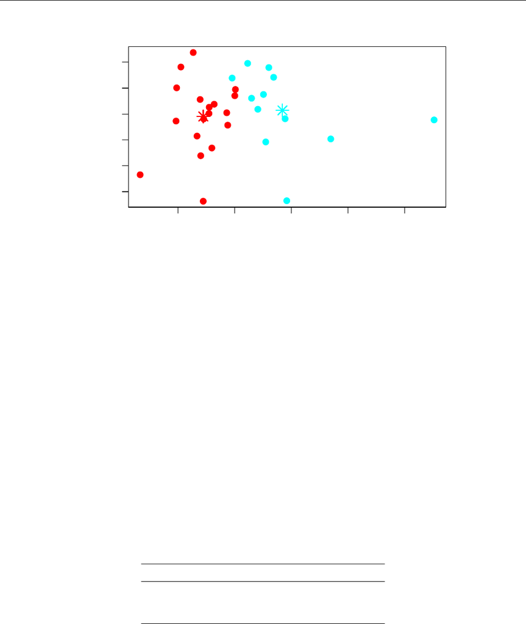

CONTRIBUTED RESEARCH ARTICLE 9

> plot(fkm.NBA, pca = TRUE)

−2 0 2 4 6

−3 −2 −1 0 1 2

Explained variance by these two components: 34.58%

Principal Component 1

Principal Component 2

Figure 2:

Scatterplot of the NBA teams on the plane spanned by the ﬁrst two principal components.

Points are marked according to the obtained partition (Cluster 1: red, Cluster 2: cyan).

In order to interpret the clusters, we inspect the prototypes. To this purpose, we apply the function

Hraw to visualize the prototypes by using the original units of measurement.

> round(Hraw(X = X.NBA, H = fkm.NBA$H), 3)

FGP 3PP FTP OREB DREB AST TOV STL BLK BLKA

Clus 1 0.451 0.358 0.759 9.830 33.757 22.483 14.252 7.446 4.581 4.996

Clus 2 0.474 0.367 0.780 9.513 33.891 24.425 14.305 8.096 5.145 4.548

PTS

Clus 1 104.362

Clus 2 109.357

We can see that Cluster 2 recognizes the best teams. In fact, the values of the prototype of Cluster

2 are better than the corresponding ones of Cluster 1, except for a few variables such as

OREB

and

Conference

and

Playoff

.

In particular, we aim at discovering whether the two clusters can be interpreted in terms of the

geographical location and/or the playoff appearance. From a statistical point of view, this consists in

comparing the fuzzy partition resulting from

FKM

with the hard ones corresponding to the classiﬁcation

variables Conference or Playoff. For this purpose, the fuzzy cluster similarity measures available in

the package are considered. Such measures, proposed by Campello (2007), are summarized in Table 3.

Function Index

RI.F Fuzzy version of Rand index

ARI.F Fuzzy version of adjusted Rand index

JACCARD.F Fuzzy version of Jaccard index

Table 3: List of fuzzy cluster similarity measures available in the package fclust.

To report the values of the three measures, the function

Fclust.compare

can be used. The input

required by

Fclust.compare

(and similarly for

RI.F

,

ARI.F

and

JACCARD.F

) is a fuzzy membership

degree matrix (U) and a vector of class labels (VC).

> Fclust.compare(VC = NBA$Playoff, U = fkm.NBA$U)

ARI.F RI.F JACCARD.F

0.3077549 0.6537339 0.4825140

The R Journal Vol. 11/01, June 2019 ISSN 2073-4859

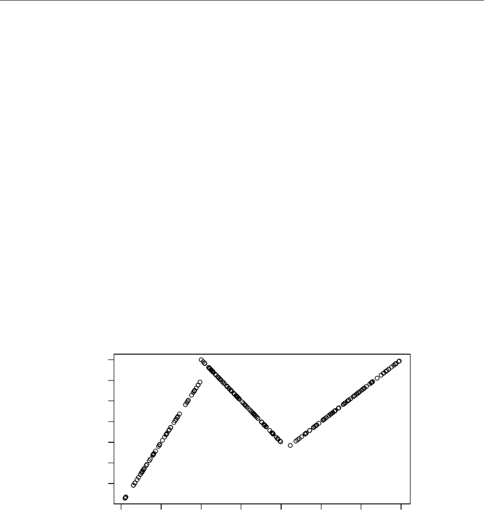

CONTRIBUTED RESEARCH ARTICLE 10

> Fclust.compare(VC = NBA$Conference, U = fkm.NBA$U)

ARI.F RI.F JACCARD.F

-0.02547957 0.48701485 0.31724090

It is clear that the clusters cannot be interpreted from a geographical point of view, whilst, to some

extent, they are related to the playoff appearance. Such a comment holds especially for Cluster 2. In

fact, 11 out of 12 teams belonging to Cluster 2 reached the playoff stage. The only exception is

Denver

Nuggets

, which was one of the best teams in terms of number of wins (

W

) but not qualiﬁed to the

playoff stage, because the number of wins was not sufﬁcient to reach the playoff stage in the Western

conference.

Gustafson-Kessel extensions of the FKM algorithm (FKM.gk and FKM.gkb)

The Gustafson-Kessel extension of the F

k

M algorithm is implemented in the functions

FKM.gk

and

FKM.gkb

. The former implements the GK-F

k

M algorithm in the original proposal, whilst the latter,

recently added to the package, considers the computational improvement suggested by Babuska

et al. (2002). A simulated dataset similar to the one in Babuska et al. (2002) is used to show the

differences between the two functions. Three different clusters with different size (100, 80, and 60) in

two-dimensional space are generated as follows:

y =

(

6 − 2.0x with x ∼ U(1,3) for Cluster 1,

−5 + 1.5x with x ∼ U(3.2, 6) for Cluster 2,

3x with x ∼ U(−1, 1) for Cluster 3.

(5)

Data can be found in fclust and loaded with the following command:

> data(synt.data2)

Figure 3 shows the scatterplot of the simulated data. In this case the cluster covariance matrices are

singular because the two variables are perfectly collinear in all the clusters.

−1 0 1 2 3 4 5 6

−2 −1 0 1 2 3 4

x

y

Figure 3: Scatterplot of the synt.data2 dataset.

By employing the standard function

FKM.gk

numerical problems occur. By setting

m = 2

,

k = 3

and RS = 1, we have:

> fkm.gk.synt <- FKM.gk(X = synt.data2, k = 3, RS = 1)

The following warning message appears:

Warning message:

In FKM.gk(X = synt.data2, k = 3, RS = 1) :

When k=3, at least one cluster covariance matrix seems to be singular.

Increase the number of starts RS or use FKM.gkb

The R Journal Vol. 11/01, June 2019 ISSN 2073-4859

CONTRIBUTED RESEARCH ARTICLE 11

Thus, we can see that the algorithm stops because at least one cluster covariance matrix is singular. In

this case, the function returns the standard object of class

fclust

containing the sub-optimal solution

at the previous iteration, i. e. the one with no singular cluster covariance matrices. By studying the

number of iterations and the loss function value of such a local optimum solution, we get:

> fkm.gk.synt$iter

Start 1

13

> fkm.gk.synt$value

Start 1

0.06044555

For comparative purpose, we run the recommended function FKM.gkb using the same start:

> fkm.gkb.synt <- FKM.gkb(X = synt.data2, k = 3, RS = 1, seed = 123)

> fkm.gkb.synt$iter

Start 1

16

> fkm.gkb.synt$value

Start 1

1.482029e-05

Fuzzy clustering for indirect relational data (dichotomous variables)

The NEFRC algorithm can be applied using the function

NEFRC

. Differently from the other functions

for clustering object data, it requires distances/dissimilarities as input argument. Consistently with

select the optimal number of clusters

k

. In particular, the silhouette index (

SIL

) and its fuzzy extension

(

SIL.F

) have been rearranged for relational data. Speciﬁcally, the input of

NEFRC

is employed to

compute the silhouette and the fuzzy silhouette indices. This is the default option when

SIL.F

is called

by

NEFRC

. In order to use the distance/dissimilarity matrix for computing the fuzzy silhouette index,

the option

distance = TRUE

in

SIL.F

should be set. Generally speaking, the fuzzy silhouette index

can be applied for any kind of data (quantitative or qualitative or mixed) provided that a suitable

distance/dissimilarity matrix is used as input.

The function

NEFRC

is presented by considering the congressional voting records data (Schlimmer,

1987) available in

fclust

Representative congressmen on 16 key votes identiﬁed by the Congressional Quartely Almanac (CQA).

The congressmen are split into Democrats and Republicans (variable

class

). The 16 key votes are

objects of class

factor

with three levels according to the CQA scheme:

y

refers to the types of votes

“voted for”, “paired for” and “announced for”;

n

to “voted against”, “paired against” and “announced

against”;

yn

to “voted present”, “voted present to avoid conﬂict of interest” and “did not vote or

otherwise make a position known”.

The dataset can be loaded as follows:

> data("houseVotes")

It contains the following variables:

> colnames(houseVotes)

[1] "class" "handicapped-infants"

[3] "water-project-cost-sharing" "adoption-of-the-budget-resolution"

[5] "physician-fee-freeze" "el-salvador-aid"

[7] "religious-groups-in-schools" "anti-satellite-test-ban"

[9] "aid-to-nicaraguan-contras" "mx-missile"

The R Journal Vol. 11/01, June 2019 ISSN 2073-4859

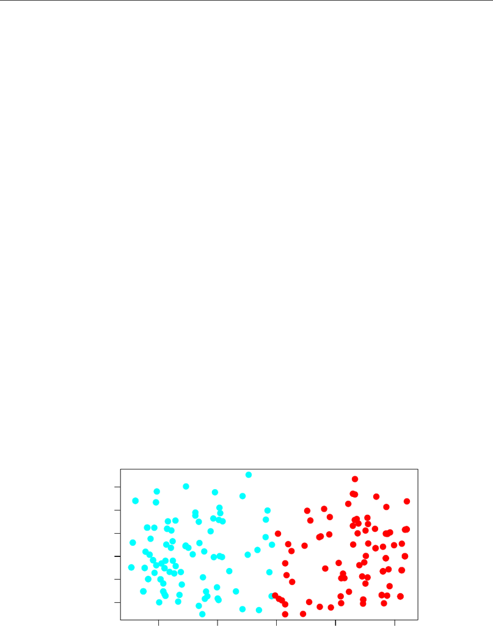

CONTRIBUTED RESEARCH ARTICLE 12

[11] "immigration" "synfuels-corporation-cutback"

[13] "education-spending" "superfund-right-to-sue"

[15] "crime" "duty-free-exports"

[17] "export-administration-act-south-africa"

Since the level

yn

might indicate unknown preferences for some key votes, these values are considered

as missing and, therefore, the rows with at least one yn value are removed:

> level.drop <- droplevels(houseVotes, exclude = "yn")

> houseVotesComplete <- level.drop[complete.cases(level.drop),]

The research interest relies in discovering whether a two-cluster structure exists and a relationship

between the political position and the system of voting emerges. Even if the dataset is not relational,

NEFRC

is the only one

R

routine for getting a fuzzy partition based on qualitative variables. For this

purpose, the Gower distance, implemented in the function

daisy

of the package

cluster

, is used to

generate the dissimilarity matrix:

> X.houseVotesComplete <- houseVotesComplete[,-1]

> library(cluster)

> D.houseVotes <- daisy(x = X.houseVotesComplete, metric = "gower")

The standard algorithm for relational data is employed by running the function

NEFRC

setting

m = 1.5

and k = 2 in order to assess whether the clusters are related to the parties (class).

> nefrc.houseVotes <- NEFRC(D = D.houseVotes, k = 2, m = 1.5, index = "SIL.F")

The

summary

method is similar to that of

FKM

and hence not reported. The two clusters can be

interpreted in terms of the parties. In fact, we get the following cluster similarity measures:

> Fclust.compare(VC = houseVotesComplete$class, U = nefrc.houseVotes$U)

ARI.F RI.F JACCARD.F

0.4871095 0.7435544 0.5914710

Morevover, we have:

> table(nefrc.houseVotes$clus[,1], houseVotesComplete$class)

democrat republican

1 19 101

2 105 7

> plot(nefrc.houseVotes)

−0.4 −0.2 0.0 0.2 0.4

−0.2 0.0 0.1 0.2 0.3

Component 1

Component 2

Figure 4:

Scatterplot of relational data with

plot

method. Points are marked according to the obtained

classiﬁcation (Cluster 1: red, Cluster 2: cyan).

The R Journal Vol. 11/01, June 2019 ISSN 2073-4859

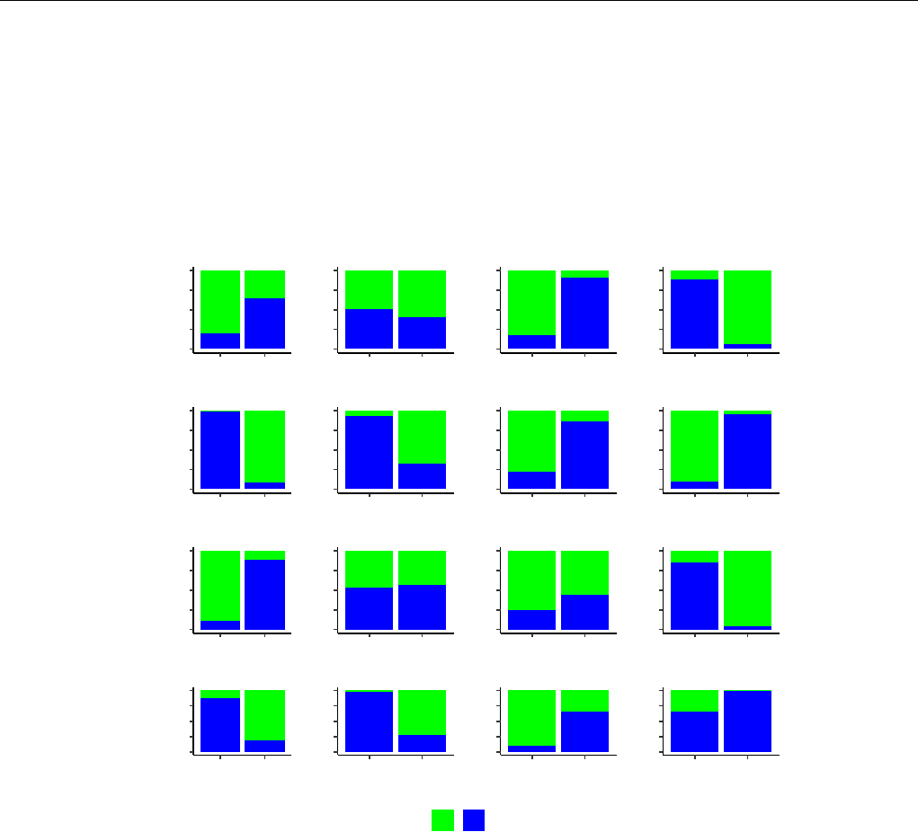

CONTRIBUTED RESEARCH ARTICLE 13

Therefore, Cluster 1 and Cluster 2 refer to the Republicans and Democrats, respectively. In Figure 4

the clusters are plotted in the low dimensional space spanned by the ﬁrst two components. Note that

the

plot

method for relational data is based on non-metric multidimensional scaling (Kruskal, 1964)

by calling the function isoMDS of the package MASS (Venables and Ripley, 2002).

To further interpret the clusters, Figure 5 displays the barplots of the 16 key votes for the two

clusters (by considering the closest hard clustering partition). We can observe that the votes are

highly connected with the Congressmen political positions. This holds for almost all the 16 key

votes with particular reference to, e. g.

"adoption-of-the-budget"

,

and

"anti-satellite-test-ban".

0.00

0.25

0.50

0.75

1.00

Clus 1 Clus 2

handicapped−infants

0.00

0.25

0.50

0.75

1.00

Clus 1 Clus 2

water−project−cost

0.00

0.25

0.50

0.75

1.00

Clus 1 Clus 2

adoption−of−the−budget

0.00

0.25

0.50

0.75

1.00

Clus 1 Clus 2

physician−fee−freeze

0.00

0.25

0.50

0.75

1.00

Clus 1 Clus 2

el−salvador−aid

0.00

0.25

0.50

0.75

1.00

Clus 1 Clus 2

religious−groups

0.00

0.25

0.50

0.75

1.00

Clus 1 Clus 2

anti−satellite−test−ban

0.00

0.25

0.50

0.75

1.00

Clus 1 Clus 2

aid−to−nicaraguan

0.00

0.25

0.50

0.75

1.00

Clus 1 Clus 2

mx−missile

0.00

0.25

0.50

0.75

1.00

Clus 1 Clus 2

immigration

0.00

0.25

0.50

0.75

1.00

Clus 1 Clus 2

synfuels−corporation

0.00

0.25

0.50

0.75

1.00

Clus 1 Clus 2

education−spending

0.00

0.25

0.50

0.75

1.00

Clus 1 Clus 2

superfund−right

0.00

0.25

0.50

0.75

1.00

Clus 1 Clus 2

crime

0.00

0.25

0.50

0.75

1.00

Clus 1 Clus 2

duty−free−exports

0.00

0.25

0.50

0.75

1.00

Clus 1 Clus 2

export−administration

n y

Figure 5: Barplot of the 16 key votes for the two clusters (n: green, y: blue).

Fuzzy clustering for indirect relational data (ordinal variables)

In this section, a dataset with ordinal data is analyzed by using

NEFRC

. The data refer to the Math

Anxiety Scale Survey administered to 20 students in a statistics course (Bai et al., 2009). In the survey,

each student answers 14 questions by using a Likert scale with ﬁve levels (

"Strongly Disagree"

,

"Disagree", "Neutral", "Agree", "Strongly Agree"). First, we load the dataset:

> library(likert)

> data("mass")

Then, we compute the dissimilarity matrix by using the Gower distance. When applied to ordinal

variables, such a distance is based on ranks. Note that the ﬁrst variable of

mass

is

Gender

, not useful

for clustering purposes and, thus, omitted in the computation of the dissimilarity matrix. We have:

> library(cluster)

> D.mass <- daisy(x = mass[,-1], metric = "gower")

Finally, we run the function NEFRC automatically selecting the number of clusters by means of SIL.F:

> nefrc.mass <- NEFRC(D = D.mass, index = "SIL.F")

The R Journal Vol. 11/01, June 2019 ISSN 2073-4859

CONTRIBUTED RESEARCH ARTICLE 14

The fuzzy silhouette values, employed to select the number of clusters, are:

> nefrc.mass$criterion

SIL.F k=2 SIL.F k=3 SIL.F k=4 SIL.F k=5 SIL.F k=6

0.5330319 0.4623684 0.4039311 0.4428360 0.4685703

Hence,

k =

2 clusters are suggested. Since the default options are used, the solution could also be

obtained by considering the function Fclust:

> nefrc.mass <- Fclust(X = D.mass, k = 2, noise = FALSE, distance = TRUE)

The clusters can be interpreted according to the observed qualitative variables. For this purpose, we

calculate the p-values resulting from the

χ

2

tests by which we study the independence between the

closest hard clustering partition and every observed variables. The p-values are stored in the vector

PV:

> PV <- rep(NA,ncol(mass))

> for (j in 1:ncol(mass)) PV[j] <- chisq.test(nefrc.mass$clus[,1], mass[,j])$p.value

At the signiﬁcance level

α =

0.05, we are interested in those variables such that the corresponding

p-value is lower than α:

> alpha <- 0.05

> names(mass)[PV < alpha]

[1] "I find math interesting."

[2] "I get uptight during math tests."

[3] "Mind goes blank and I am unable to think clearly when doing my math test."

[4] "I worry about my ability to solve math problems."

[5] "I get a sinking feeling when I try to do math problems."

[6] "I find math challenging."

[7] "Mathematics makes me feel nervous."

[8] "Mathematics makes me feel uneasy."

[9] "Math is one of my favorite subjects."

[10] "I enjoy learning with mathematics."

[11] "Mathematics makes me feel confused."

We inspect the contingency tables (not reported here) between such a subset of observed variables

and the closest hard clustering partition and we ﬁnd that Cluster 1 is characterized by large fre-

quencies for the modalities

"Strongly Disagree"

and

"Disagree"

with respect to the variables

"I

find math interesting."

,

"Math is one of my favorite subjects."

and

"I enjoy learning

with mathematics."

and large frequencies for the modalities

"Agree"

and

"Strongly Agree"

with

respect to the variables

"I get uptight during math tests."

,

"Mind goes blank and I am unable

to think clearly when doing my math test."

,

"I worry about my ability to solve math

problems."

,

"I get a sinking feeling when I try to do math problems."

,

"I find math

challenging."

,

"Mathematics makes me feel nervous."

,

"Mathematics makes me feel uneasy."

and

"Mathematics makes me feel confused."

. Of course, the opposite comment holds for Cluster 2.

Therefore, the partition distinguishes the students liking math (assigned to Cluster 2) from those who

experience feelings of stress when faced with math (assigned to Cluster 1).

Fuzzy clustering for direct relational data

In the previous two subsections,

NEFRC

is applied in order to discover homogeneous clusters of

observations on which qualitative variables are collected. In these cases, suitable dissimilarity matrices

are built before running

NEFRC

. In the current subsection, we consider the case where variables are not

available and the only information about the observations is expressed in terms of their dissimilarities

or distances. The data are stored in the following object of class dist:

> library(smacof)

> data("FaceExp")

FaceExp

contains the dissimilarities between pairs of 13 facial expressions related to particular stimuli:

> labels(FaceExp)

The R Journal Vol. 11/01, June 2019 ISSN 2073-4859

CONTRIBUTED RESEARCH ARTICLE 15

[1] "Grief at death of mother" "Savoring a Coke"

[3] "Very pleasant surprise" "Maternal love-baby in arms"

[5] "Physical exhaustion" "Something wrong with plane"

[7] "Anger at seeing dog beaten" "Pulling hard on seat of chair"

[9] "Unexpectedly meets old boyfriend" "Revulsion"

[11] "Extreme pain" "Knows plane will crash"

[13] "Light sleep"

The dissimilarities have been calculated in a psychological experiment where a set of subjects were

invited to judge how much two pictures of emotional expressions differ. Thus, all the possible pairs of

emotional expressions were compared by the subjects and the dissimilarities were derived. See, for

further details, Abelson and Sermat (1962) .

By means of

NEFRC

the aim is to discover whether similar facial expressions are perceived by the

subjects in connection with similar emotions intended by the stimuli. In this case, we do not know the

number of clusters and, therefore, we determine it according to SIL.F.

> nefrc.FaceExp <- NEFRC(D = FaceExp, index = "SIL.F")

We ﬁnd that k = 3 should be set:

> nefrc.FaceExp$criterion

SIL.F k=2 SIL.F k=3 SIL.F k=4 SIL.F k=5 SIL.F k=6

0.5298465 0.5929045 0.5470887 0.5436513 0.4003177

The interpretation of the clusters can be done by seeking a common feature for the facial expressions, i.

e. the stimuli, assigned to the same cluster. We have:

> round(nefrc.FaceExp$clus[(nefrc.FaceExp$clus[,1] == 1), 2], 2)

Savoring a Coke Very pleasant surprise Maternal love-baby in arms

0.64 0.85 0.75

Pulling hard on seat Unexpectedly meets old boyfriend

0.59 0.94

> round(nefrc.FaceExp$clus[(nefrc.FaceExp$clus[,1] == 2), 2], 2)

Grief at death of mother Physical exhaustion Revulsion

0.79 0.81 0.69

Extreme pain Light sleep

0.56 0.64

> round(nefrc.FaceExp$clus[(nefrc.FaceExp$clus[,1] == 3), 2], 2)

Something wrong with plane Anger at seeing dog beaten Knows plane will crash

0.52 0.93 0.78

Cluster 1 groups pleasant stimuli with the only exception of

"Pulling hard on seat of chair"

for

which the membership degree is however the lowest one (

0.59

). The facial expressions showing pain

belong to Cluster 2.

"Light sleep"

is also assigned to the cluster. It follows that the subjects tend to

associate such an expression with suffering. Finally, anxiety characterizes Cluster 3.

Conclusion

In this paper we have described the main features of the package

fclust

.

fclust

represents a toolbox

for fuzzy cluster analysis. The functions in the package offer a wide range of fuzzy clustering

algorithms, fuzzy cluster validity indices, measures of similarity for comparing hard and fuzzy

partitions and visualization tools for fuzzy clustering results. Particular attention has been paid to the

new improvements and implementations available in the current version of the package (version 2.1.1).

First of all, the functions have been updated by using the C++ language, with a remarkable reduction

in computation time. Furthermore, the package now includes some fuzzy clustering algorithms

for relational data, allowing the user to perform a fuzzy clustering analysis when the variables are

qualitative or mixed. In such cases, a dissimilarity matrix can be built by using the existing R functions

(e. g.

dist

or

daisy

in the package

cluster

) and the available functions for relational data (

NEFRC

and

NEFRC.noise

) can then be applied. As far as we know,

NEFRC

and

NEFRC.noise

represent the ﬁrst

The R Journal Vol. 11/01, June 2019 ISSN 2073-4859

CONTRIBUTED RESEARCH ARTICLE 16

available

R

functions for fuzzy clustering of qualitative or mixed variables. All the functions have been

revised in such a way that the number of clusters can be automatically selected. This might increase

the computation time, but it is crucial in order to spread the use of fuzzy clustering methods especially

for non-expert users. In this connection, the function

Fclust

for running the available algorithms

using the default options and specifying the desired number of clusters is also offered.

Bibliography

R. P. Abelson and V. Sermat. Multidimensional scaling of facial expressions. Journal of Experimental

Psychology, 63(6):546–554, 1962. URL http://dx.doi.org/10.1037/h0042280. [p15]

R. Babuska, P. J. Van der Veen, and U. Kaymak. Improved covariance estimation for gustafson-kessel

clustering. In Proceedings of the 2002 IEEE International Conference on Fuzzy Systems, page 1081–1085,

2002. URL https://doi.org/10.1109/FUZZ.2002.1006654. [p4, 5, 6, 10]

H. Bai, L. Wang, W. Pan, and M. Frey. Measuring mathematics anxiety: Psychometric analysis

of a bidimensional affective scale. Journal of Instructional Psychology, 36(3):185–193, 2009. URL

https://eric.ed.gov/?id=EJ952267. [p13]

J. C. Bezdek. Pattern Recognition with Fuzzy Objective Function Algorithms. Plenum Press, New York,

1981. [p2, 3, 5]

R. J. Campello. A fuzzy extension of the Rand index and other related indexes for clustering and

classiﬁcation assessment. Pattern Recognition Letters, 28(7):833–841, 2007. URL

https://dx.doi.

org/10.1016/j.patrec.2006.11.010. [p2, 6, 9]

Z. Cebeci, F. Yildiz, A. T. Kavlak, C. Cebeci, and H. Onder. ppclust: Probabilistic and Possibilistic Cluster

Analysis, 2018. URL

https://CRAN.R-project.org/package=ppclust

. R package version 0.1.1. [p2]

N. C. Chung, B. Miasojedow, M. Startek, and A. Gambin. Jaccard: Test Similarity Between Binary Data

Using Jaccard/Tanimoto Coefﬁcients, 2018. URL

https://CRAN.R-project.org/package=jaccard

. R

package version 0.1.0. [p2]

R. N. Davé. Characterization and detection of noise in clustering. Pattern Recognition Letters, 12(11):

657–664, 1991. URL https://doi.org/10.1016/0167-8655(91)90002-4. [p5]

R. N. Davé and S. Sen. Robust fuzzy clustering of relational data. IEEE Transactions on Fuzzy Systems,

10(6):713–727, 2002. URL https://dx.doi.org/10.1109/TFUZZ.2002.805899. [p2, 3, 4, 5]

M. De Caceres, X. Font, and F. Oliva. The management of vegetation classiﬁcations with fuzzy

clustering. Journal of Vegetation Science, 21:1138–1151, 2010. URL

https://doi.org/10.1111/j.1654-

1103.2010.01211.x. [p2]

J. de Leeuw and P. Mair. Multidimensional scaling using majorization: SMACOF in R. Journal of

Statistical Software, 31(3):1–30, 2009. URL http://www.jstatsoft.org/v31/i03/. [p4]

D. Eddelbuettel. Seamless R and C++ Integration with Rcpp. Springer-Verlag, New York, 2013. URL

https://doi.org/10.1007/978-1-4614-6868-4. [p2]

D. Eddelbuettel and C. Sanderson. Rcpparmadillo: Accelerating r with high-performance c++ linear

algebra. Computational Statistics & Data Analysis, 71:1054–1063, 2014. URL

https://dx.doi.org/10.

1016/j.csda.2013.02.005. [p2]

M. B. Ferraro and P. Giordani. A new fuzzy clustering algorithm with entropy regularization. In

Proceedings of the 9th Scientiﬁc Meeting of the Classiﬁcation and Data Analysis Group (CLADAG 2013),

2013. ISBN 9788867871179. [p5]

M. B. Ferraro and P. Giordani. A toolbox for fuzzy clustering using the r programming language. Fuzzy

Sets and Systems, 279:1–16, 2015. URL https://dx.doi.org/10.1016/j.fss.2015.05.001. [p2]

J. C. Gower. A general coefﬁcient of similarity and some of its properties. Biometrics, 27(4):857–871,

1971. URL https://doi.org/10.2307/2528823. [p2]

D. E. Gustafson and W. C. Kessel. Fuzzy clustering with a fuzzy covariance matrix. In Proceedings of

the 1978 IEEE Conference on Decision and Control Including the 17th Symposium on Adaptive Processes,

page 761–766, 1979. URL https://doi.org/10.1109/CDC.1978.268028. [p3, 5]

The R Journal Vol. 11/01, June 2019 ISSN 2073-4859

CONTRIBUTED RESEARCH ARTICLE 17

M. Halkidi, Y. Batistakis, and M. Vazirgiannis. On clustering validation techniques. Journal of Intelligent

Information Systems, 17(2-3):107–145, 2001. URL

https://doi.org/10.1023/A:1012801612483

. [p2]

J. A. Hartigan and M. A. Wong. Algorithm as 136: A K-means clustering algorithm. Journal of the Royal

Statistical Society. Series C (Applied Statistics), 28(1):100–108, 1979. URL

https://doi.org/10.2307/

2346830. [p1]

K. Hornik. A CLUE for CLUster Ensembles. Journal of Statistical Software, 14(12):1–25, 2005. URL

https://doi.org/10.18637/jss.v014.i12. [p2]

K. Hornik, I. Feinerer, M. Kober, and C. Buchta. Spherical

k

-means clustering. Journal of Statistical

Software, 50(10):1–22, 2012. URL https://doi.org/10.18637/jss.v050.i10. [p2]

L. Hubert and P. Arabie. Comparing partitions. Journal of Classiﬁcation, 2(1):193–218, 1985. URL

https://dx.doi.org/10.1007/BF01908075. [p2]

P. Jaccard. Étude comparative de la distribution ﬂorale dans une portion des alpes et des jura. Bulletin

del la Société Vaudoise des Sciences Naturelles, 37:547–579, 1901. [p2]

L. Kaufman and P. J. Rousseeuw. Finding Groups in Data: An Introduction to Cluster Analysis. John Wiley

& Sons, New York, 1990. URL https://doi.org/10.2307/2532178. [p4, 6]

R. Krishnapuram, A. Joshi, O. Nasraoui, and L. Yi. Low-complexity fuzzy relational clustering

algorithms for web mining. IEEE Transactions on Fuzzy Systems, 9(4):595–607, 2001. URL

https:

//doi.org/10.1109/91.940971. [p5]

J. B. Kruskal. Nonmetric multidimensional scaling: a numerical method. Psychometrika, 29(2):115–129,

1964. URL https://doi.org/10.1007/BF02289694. [p13]

R.-P. Li and M. Mukaidono. A maximum-entropy approach to fuzzy clustering. In Proceedings of 1995

IEEE International Conference on Fuzzy Systems, page 2227–2232, 1995. URL

https://doi.org/10.

1109/FUZZY.1995.409989. [p5]

R.-P. Li and M. Mukaidono. Gaussian clustering method based on maximum-fuzzy-entropy inter-

pretation. Fuzzy Sets and Systems, 102(2):253–258, 1999. URL

https://doi.org/10.1016/S0165-

0114(97)00126-7. [p5]

M. Maechler, P. Rousseeuw, A. Struyf, M. Hubert, and K. Hornik. Cluster: Cluster Analysis Basics and

Extensions, 2017. URL

https://cran.r-project.org/web/packages/cluster

. R package version

2.0.6. [p2]

D. Meyer, E. Dimitriadou, K. Hornik, A. Weingessel, and F. Leisch. E1071: Misc Functions of the

Department of Statistics, Probability Theory Group (Formerly: E1071), TU Wien, 2017. URL

https:

//CRAN.R-project.org/package=e1071. R package version 1.6-8. [p2]

W. M. Rand. Objective criteria for the evaluation of clustering methods. Journal of the American

Statistical Association, 66(33):846–850, 1971. URL https://dx.doi.org/10.2307/2284239. [p2]

E. H. Ruspini. Numerical methods for fuzzy clustering. Information Sciences, 2(3):319–350, 1970. URL

https://doi.org/10.1016/S0020-0255(70)80056-1. [p1]

J. C. Schlimmer. Concept Acquisition through Representational Adjustment. Department of Information

and Computer Science, University of California, Irvine, 1987. [p11]

L. Scrucca, M. Fop, T. B. Murphy, and A. E. Raftery. mclust 5: Clustering, Classiﬁcation and Density

Estimation Using Gaussian Finite Mixture Models. The R Journal, 8(1):289–317, 2016. URL

https:

//journal.r-project.org/archive/2016/RJ-2016-021/index.html. [p2]

W. N. Venables and B. D. Ripley. Modern Applied Statistics with S. Springer-Verlag, New York, 2002.

URL https://doi.org/10.1007/978-0-387-21706-2. [p13]

R. Winkler, F. Klawonn, F. Höppner, and R. Kruse. Fuzzy cluster analysis of larger data sets. In Scalable

Fuzzy Algorithms for Data Management and Analysis: Methods and Design, page 302–331. IGI Global,

Hershey, 2009. URL https://doi.org/10.4018/978-1-60566-858-1.ch012. [p5]

R. Winkler, F. Klawonn, and R. Kruse. Fuzzy clustering with polynomial fuzziﬁer function in connec-

tion with m-estimators. Applied and Computational Mathematics, 10(1):146–163, 2011. [p5]

The R Journal Vol. 11/01, June 2019 ISSN 2073-4859

CONTRIBUTED RESEARCH ARTICLE 18

Maria Brigida Ferraro

Department of Statistical Sciences, Sapienza University of Rome

P.le Aldo Moro 5, 00185 Rome, Italy

ORCiD: 0000-0002-7686-5938

mariabrigida.ferraro@uniroma1.it

Paolo Giordani

Department of Statistical Sciences, Sapienza University of Rome

P.le Aldo Moro 5, 00185 Rome, Italy

ORCiD: 0000-0003-4091-3165

paolo.giordani@uniroma1.it

Alessio Seraﬁni

Department of Statistical Sciences, Sapienza University of Rome

P.le Aldo Moro 5, 00185 Rome, Italy

ORCiD: 0000-0002-8579-5695

alessio.serafini@uniroma1.it

The R Journal Vol. 11/01, June 2019 ISSN 2073-4859